# Project Plan & EDA

W06G08

2025-05-25

```r
library(ggplot2)
library(dplyr)
library(tidyr)
library(cowplot)
library(gridExtra)
library(corrplot)
library(GGally)
library(factoextra)
library(readxl)
library(kknn)
library(caret)
library(MASS)
library(e1071)
library(randomForest)
library(reshape2)
library(knitr)
library(nnet)
library(glmnet)
library(tibble)
```

## 1.Problem Overview

The objective is to predict occupation based on individuals’ socio-economic and demographic characteristics (such as age, education, relationship, etc.).This classification is helpful for recommending suitable occupations based on personal characteristics, and it can also help formulate corresponding educational and training plans according to the requirements of the occupations.

## 2.Dataset Description, Cleaning and Preparation

### 2.1 Describe the Data

The dataset used in this project is derived from the 1994 US Census and contains 48,842 records. Each record contains 15 characteristics and is used to describe an individual’s socioeconomic and demographic characteristics. These features include both numerical variables (such as age, education.num, hours.per.week)and categorical variables (such as workclass, marital.status, occupation, race, gender, native.country). The target variable of this study is “occupation”, which initially contains 14 categories. Multiple variables show high cardinality and class imbalance, and there are missing values in occupation, workclass and native.country.

### 2.2 Handle missing values and duplicate values

In the first step of data cleaning, we examined the structure of the original data set and converted all “?” entries into standard missing values NA for unified processing. The following R code summarizes the statistics of missing values in each column:

```r
adult_data = read.csv('adult.csv',na.strings = "?")
sapply(adult_data,function(x) sum(is.na(x)))
```

```
##             age       workclass          fnlwgt       education educational.num
##               0            2799               0               0               0
##  marital.status      occupation    relationship            race          gender
##               0            2809               0               0               0
##    capital.gain    capital.loss  hours.per.week  native.country          income
##               0               0               0             857               0
```

We then proceeded to handle missing values and duplicates as follows:  
1. For the input variables workclass and native.country, we first converted them to character type to ensure correct assignment. Then, their missing values are filled with the new “Unknown” category instead of deleting the corresponding rows. Because this not only avoids deleting a large amount of data, but also enables the model to identify the possible predictive value of the missing information itself, maintaining data integrity and modeling rationality.  
2. For the target variable occupation, we deleted all rows with missing labels (2809 samples). Because in supervised learning tasks, data without labels cannot participate in model training or evaluation, as the model cannot learn the mapping relationship of “input features → output occupational categories”. Meanwhile, attempting to fill in the label values (such as using mode or model prediction) will not only introduce incorrect labels, but also may lead to model mislearning, bias, and reduce the final performance.  
3. For duplicate records, we use the duplicated() function to identify and delete completely duplicate rows, ensuring that each sample in the dataset is unique.

```r
adult_data$workclass <- as.character(adult_data$workclass)
adult_data$native.country <- as.character(adult_data$native.country)

adult_data$workclass[is.na(adult_data$workclass)] <- "Unknown"
adult_data$native.country[is.na(adult_data$native.country)] <- "Unknown"

adult_data <- adult_data[!is.na(adult_data$occupation), ]

adult_data <- adult_data[!duplicated(adult_data), ]
```

After dealing with the missing values and duplicate values, we retained 45,985 unique and complete samples from the original 48,842 records as the cleaned dataset of our classification model.

### 2.3 Delete useless or redundant variables

In this section, we combined domain knowledge and the statistical characteristics of variables to evaluate the value of each feature for the occupational classification task, and removed some variables that were considered to be information-redundant, have limited contributions, or may affect the performance of the model. The specific handling is as follows:  
1. **fnlwgt**:This field represents the sample weights in the census and is used to expand the sample to the overall population size. It does not contain feature information directly related to the occupation. If it is not processed and incorporated into the model, it may instead introduce errors. Therefore, we choose to delete it.  
2. **education**:This is a categorical variable representing educational qualifications (such as “Bachelors”, “HS-grad”, etc.), and it is a completely correlated variable that corresponds one-to-one with education.num. Retaining both will introduce multicollinearity, especially having a significant impact on models such as logistic regression. Therefore, we choose to retain education.num because it is an ordered numerical variable, more compact, easier to model, does not require additional coding, and is more suitable for representing the level of education.  
3. **capital.gain** and **capital.loss**:Over 90% of the values in both variables are zero, a skewed distribution that makes them narrowly variable in the data and limited in their contribution to the model’s discriminatory power. So, we removed both.

```r
#sum(adult_data$capital.gain == 0) / nrow(adult_data)
#sum(adult_data$capital.loss == 0) / nrow(adult_data)
adult_cleaned <- adult_data %>%
  dplyr::select(-fnlwgt, -education, -capital.gain, -capital.loss)
```

### 2.4 Categorical Variable Grouping and Class Imbalance Handling

In this section, we will address the class imbalance and high cardinality issues between the target variable (occupation) and several categorical input variables. Highly imbalanced or sparse categorical variables may lead to poor generalization, unstable model estimation, or inflated computational costs. Therefore, we have implemented grouping and simplification strategies for the following variables to improve the model’s performance and interpretability.  
(1) Occupation:The original 14 types of target variables were divided into 5 major categories (White-Collar, Blue-Collar, Office, Sales, and Service) to reduce class imbalance and simplify the classification task.  
(2) Workclass:Merge the original seven types of jobs into four categories—Private, Self-Employed, Government, and Without-pay—to improve the representative balance and reduce the sparsity of the model.  
(3) Native Country:Since over 90% of the individuals are from the United States, we classify all other countries as “Other” and retain “Unknown” as a separate category to reduce the dimension.  
(4) Marital Status:Merge the original seven marital conditions into three categories: Married, Single, and Separated/Other.  
(5) Race:Due to extreme imbalance (White > 80%), all non-White groups were merged into a single category “Non-White”, resulting in a binary race variable (White vs. Non-White).  
(6) Relationship:Divide the original six types of relations into In-family, Unmarried, and Not-in-family to reduce redundancy and clarify semantic structure.

```r
#Check the specific distribution of these categorical variables
distribution <- lapply(adult_cleaned[, c("occupation", "workclass", "native.country", "marital.status", "race", "relationship")], table)

#(1)Target Variable: occupation
adult_cleaned$occupation_grouped <- dplyr::recode(adult_cleaned$occupation,
  "Exec-managerial" = "White-Collar",
  "Prof-specialty"  = "White-Collar",

  "Craft-repair"        = "Blue-Collar",
  "Machine-op-inspct"   = "Blue-Collar",
  "Transport-moving"    = "Blue-Collar",
  "Handlers-cleaners"   = "Blue-Collar",
  "Farming-fishing"     = "Blue-Collar",

  "Adm-clerical"  = "Office",
  "Tech-support"  = "Office",

  "Sales" = "Sales",

  "Other-service"     = "Service",
  "Protective-serv"   = "Service",
  "Priv-house-serv"   = "Service",
  "Armed-Forces"      = "Service"
)
adult_cleaned <- adult_cleaned[, c("occupation_grouped", setdiff(names(adult_cleaned), "occupation_grouped"))]

#(2)Workclass
adult_cleaned$workclass_grouped  <- dplyr::recode(adult_cleaned$workclass,
  "Private"           = "Private",
  "Self-emp-not-inc"  = "Self-Employed",
  "Self-emp-inc"      = "Self-Employed",
  "Federal-gov"       = "Government",
  "State-gov"         = "Government",
  "Local-gov"         = "Government",
  "Without-pay"       = "Without-pay"
)

#(3)native.country
adult_cleaned$native.country_grouped <- ifelse(
  adult_cleaned$native.country %in% c("United-States", "Unknown"),
  adult_cleaned$native.country,
  "Other"
)

#(4)marital.status
adult_cleaned$marital_grouped <- dplyr::recode(adult_cleaned$marital.status,
  "Married-civ-spouse"     = "Married",
  "Never-married"          = "Single",
  "Divorced"               = "Separated/Other",
  "Separated"              = "Separated/Other",
  "Widowed"                = "Separated/Other",
  "Married-spouse-absent"  = "Separated/Other",
  "Married-AF-spouse"      = "Separated/Other"
)

#(5)race
adult_cleaned$race_grouped <- ifelse(
  adult_cleaned$race == "White",
  "White",
  "Non-White"
)

#(6)relationship
adult_cleaned$relationship_grouped <- dplyr::recode(adult_cleaned$relationship,
  "Husband"         = "In-family",
  "Wife"            = "In-family",
  "Own-child"       = "In-family",
  "Other-relative"  = "In-family",
  "Unmarried"       = "Unmarried",
  "Not-in-family"   = "Not-in-family"
)

#Delete the original redundant variable column
adult_cleaned <- adult_cleaned %>%
  dplyr::select(-c(occupation, workclass, native.country, marital.status, race, relationship))
```

### 2.5 Data encoding

Converting target and other categorical variables to factor type. By converting these variables to factor type, R to treat them as categorical features. In addition, it improves model interpretability and efficiency.

```r
adult_cleaned$occupation_grouped <- as.factor(adult_cleaned$occupation_grouped)
adult_cleaned$workclass_grouped <- as.factor(adult_cleaned$workclass_grouped)
adult_cleaned$native.country_grouped <- as.factor(adult_cleaned$native.country_grouped)
adult_cleaned$marital_grouped <- as.factor(adult_cleaned$marital_grouped)
adult_cleaned$race_grouped <- as.factor(adult_cleaned$race_grouped)
adult_cleaned$relationship_grouped <- as.factor(adult_cleaned$relationship_grouped)
adult_cleaned$gender <- as.factor(adult_cleaned$gender)
adult_cleaned$income <- as.factor(adult_cleaned$income)
```

## 3.Exploratory Data Analysis

### 3.1 Overview of Target Variable

In the histogram of the target variable, although there are still some imbalances, all categories contain a sufficient number of samples that can be used for supervised classification. It is notable that Blue-Collar is the largest group, accounting for nearly one-third of the dataset, while Sales is the smallest group. This distribution provides a relatively balanced basis for training multi-category classification models.

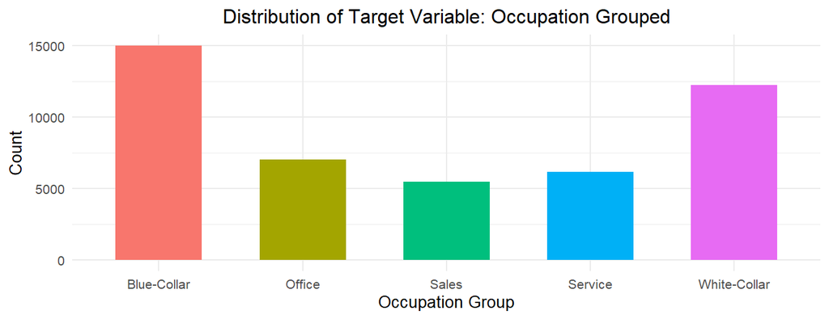

```r
options(repr.plot.width = 6, repr.plot.height = 4)
ggplot(adult_cleaned, aes(x = occupation_grouped, fill = occupation_grouped)) +
  geom_bar(width = 0.6) +
  labs(title = "Distribution of Target Variable: Occupation Grouped",
       x = "Occupation Group",
       y = "Count") +
  theme_minimal(base_size = 10) +
  theme(legend.position = "none",
        plot.title = element_text(hjust = 0.5))
```

### 3.2 Numerical variables analysis

To evaluate the discriminative ability of numerical variables for occupational categories, we drew box plots between age, education.num, and hours.per.week and occupation_grouped. The results show that these three variables have obvious structural differences from the occupational categories and have good predictive value.

In conclusion, the three numerical variables all show meaningful distribution differences among different occupational categories, providing solid feature support for the construction of the occupational prediction model.Furthermore, we examined whether there were extreme values or potential erroneous values in the three numerical variables. The maximum age observed was 90 years old, the highest years of education was 16 years, and the longest working hours per week was 99 hours. All these values are within a reasonable and reliable range, indicating that they are very likely to be real cases in the real world (for example, older professionals or self-employed individuals with longer working hours). Therefore, no outliers were removed or pruned, and all original observations were retained to ensure data integrity.

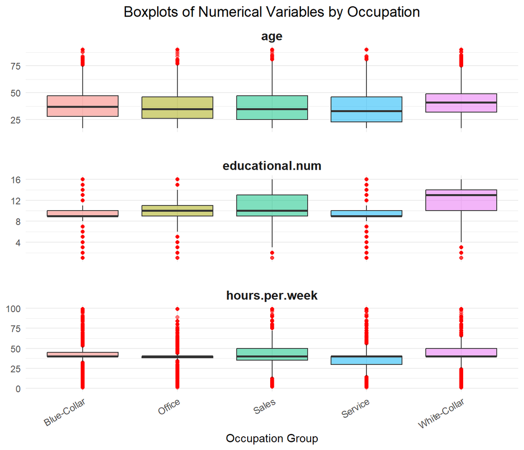

```r
num_long <- adult_cleaned %>%
  dplyr::select(occupation_grouped, age, educational.num, hours.per.week) %>%
  pivot_longer(cols = c(age, educational.num, hours.per.week),
               names_to = "Variable",
               values_to = "Value")

ggplot(num_long, aes(x = occupation_grouped, y = Value, fill = occupation_grouped)) +
  geom_boxplot(alpha = 0.5, outlier.color = "red", outlier.size = 1.5) +
  facet_wrap(~ Variable, scales = "free_y", ncol = 1) +
  labs(title = "Boxplots of Numerical Variables by Occupation",
       x = "Occupation Group", y = NULL) +
  theme_minimal(base_size = 11) +
  theme(
    legend.position = "none",
    axis.text.x = element_text(angle = 30, hjust = 1, size = 9),
    strip.text = element_text(size = 12, face = "bold"),
    plot.title = element_text(size = 14, hjust = 0.5),
    panel.spacing = unit(1.5, "lines")
  )
```

### 3.3 Categorical variables analysis

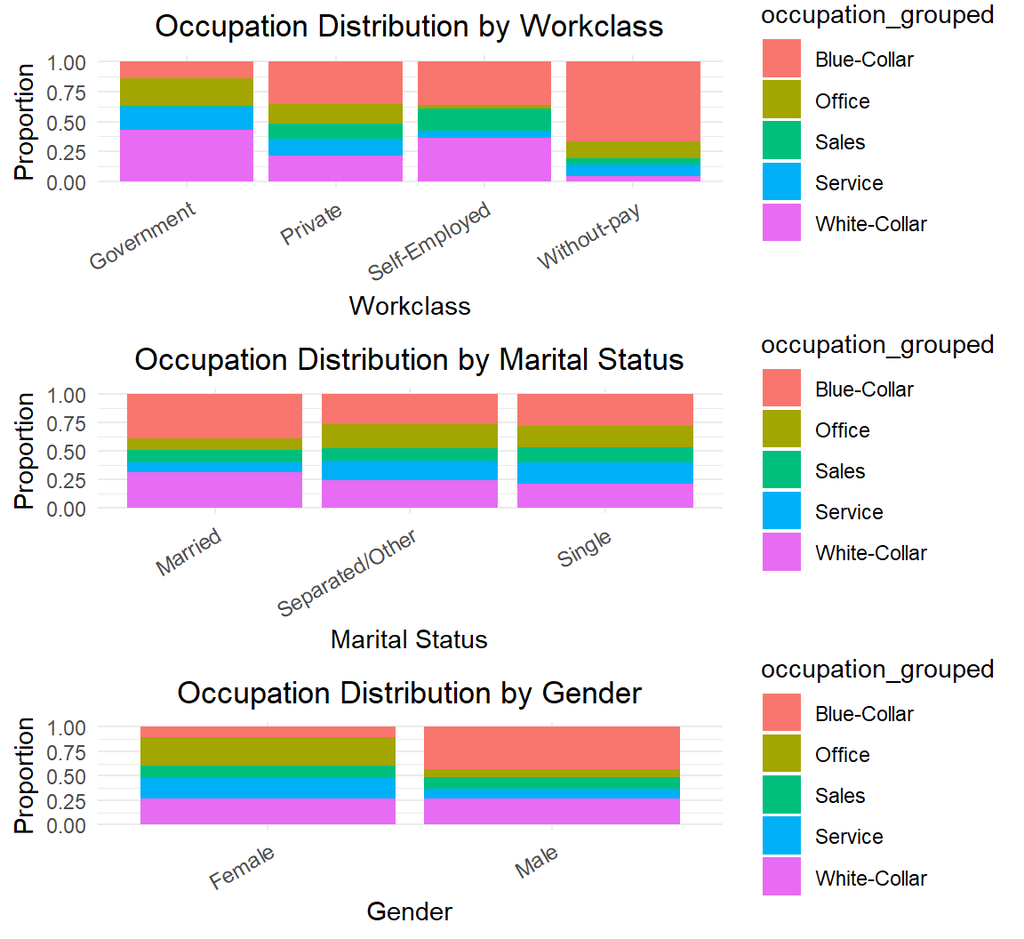

```r
base_theme <- theme_minimal(base_size = 11) +
  theme(
    axis.text.x = element_text(angle = 30, hjust = 1, size = 9),
    plot.title = element_text(hjust = 0.5, size = 13),
    legend.position = "right"
  )
p1 <- ggplot(adult_cleaned, aes(x = workclass_grouped, fill = occupation_grouped)) +
  geom_bar(position = "fill") +
  labs(title = "Occupation Distribution by Workclass",
       x = "Workclass", y = "Proportion") +
  base_theme
p2 <- ggplot(adult_cleaned, aes(x = marital_grouped, fill = occupation_grouped)) +
  geom_bar(position = "fill") +
  labs(title = "Occupation Distribution by Marital Status",
       x = "Marital Status", y = "Proportion") +
  base_theme
p3 <- ggplot(adult_cleaned, aes(x = gender, fill = occupation_grouped)) +
  geom_bar(position = "fill") +
  labs(title = "Occupation Distribution by Gender",
       x = "Gender", y = "Proportion") +
  base_theme
plot_grid(p1, p2, p3, ncol = 1, align = "v", rel_heights = c(1.1, 1.1, 0.9))
```

### 3.4 Checking numerical variable correlations

To evaluate the potential multicollinearity among numerical features, we calculated the Pearson correlation coefficients among age, educational.num and hours.per.week. As shown in the correlation matrix, all pairwise correlations are lower than 0.5, indicating a weak linear relationship. This indicates that there is no significant collinearity or redundancy among the numerical variables, and all variables can be retained for subsequent modeling.

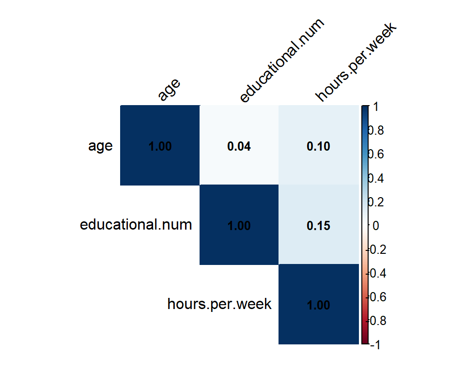

```r
numeric_data <- adult_cleaned %>% dplyr::select(age, educational.num, hours.per.week)
cor_matrix <- cor(numeric_data, method = "pearson")
corrplot(cor_matrix, method = "color", type = "upper",
         tl.col = "black", tl.srt = 45, addCoef.col = "black", number.cex = 0.8)
```

## 4.Classification Models Used

This project aims to predict an individual’s occupational category through a multi-category classification method, using socio-economic and demographic attributes. We use four supervised learning models, including multiple logistic regression, Linear Discriminant Analysis(LDA), K-Nearest Neighbors (KNN), and Random Forest, to explore different perspectives of classification. These models were chosen because they have complementary advantages in terms of interpretability, statistical basis, adaptability to nonlinear patterns, and robustness to feature diversity, and can comprehensively evaluate the accuracy of career predictions.

### Logistic Regression (multinomial)

The following code is based on the Multinomial Logistic Regression model and performs multi-classification prediction tasks for individual occupational categories. After conducting exclusive coding and standardization processing on socio-economic and demographic characteristics, the model fits on the training set and makes predictions on the test set. The final output includes the confusion matrix, various precisions, recall rates and F1 values, as well as macro average indicators and overall accuracy rates, which are used to comprehensively evaluate the performance of the model in this multi-category classification task.

```r
# One-hot Encoding
df_encoded <- model.matrix(~ . - occupation_grouped, data = adult_cleaned) %>% as.data.frame()
df_encoded$occupation_grouped <- adult_cleaned$occupation_grouped

# Split data
set.seed(5003)
split_index <- createDataPartition(df_encoded$occupation_grouped, p = 0.8, list = FALSE)
train_data <- df_encoded[split_index, ]
test_data  <- df_encoded[-split_index, ]

# Standardization
train_x <- train_data[, !names(train_data) %in% "occupation_grouped"]
test_x <- test_data[, !names(test_data) %in% "occupation_grouped"]
preProc <- preProcess(train_x, method = c("center", "scale"))
train_scaled <- predict(preProc, train_x)
test_scaled <- predict(preProc, test_x)
train_scaled$occupation_grouped <- train_data$occupation_grouped
test_scaled$occupation_grouped <- test_data$occupation_grouped

# Prepare training data
x <- as.matrix(train_scaled[, !names(train_scaled) %in% "occupation_grouped"])
y <- train_scaled$occupation_grouped
x_test <- as.matrix(test_scaled[, !names(test_scaled) %in% "occupation_grouped"])
y_test <- test_scaled$occupation_grouped

# Grid of alpha and lambda (C = 1/lambda)
alpha_values <- seq(0, 1, by = 0.25)
lambda_values <- 1 / c(0.01, 0.1, 1, 10, 100)
grid <- expand.grid(alpha = alpha_values, lambda = lambda_values)

# Train model
set.seed(5003)
log_model <- train(
  x = x,
  y = y,
  method = "glmnet",
  family = "multinomial",
  trControl = trainControl(method = "cv", number = 10),
  tuneGrid = grid
)

# Best parameters
best_alpha <- log_model$bestTune$alpha
best_lambda <- log_model$bestTune$lambda
log_best_param_df <- data.frame(
  Metric = c("Best alpha", "Best lambda"),
  Value = c(best_alpha, best_lambda)
)
kable(log_best_param_df, caption = "Logistic Regression - Best Hyperparameters")
```

Logistic Regression - Best Hyperparameters

| Metric | Value |
| --- | --- |
| Best alpha | 0.25 |
| Best lambda | 0.01 |

```r
# Ensure factor levels match
y_test <- factor(y_test, levels = levels(y))
log_pred <- predict(log_model, newdata = x_test)
log_pred <- factor(log_pred, levels = levels(y_test))

# Confusion matrix
log_conf_matrix <- confusionMatrix(log_pred, y_test)
log_acc <- mean(log_pred == y_test)

log_by_class_raw <- log_conf_matrix$byClass

if (is.matrix(log_by_class_raw)) {
  log_by_class <- as.data.frame(log_by_class_raw)
  log_by_class$Category <- rownames(log_by_class)
} else {
  log_by_class <- as.data.frame(t(as.data.frame(log_by_class_raw)))
  log_by_class$Category <- levels(y_test)[1]
}

log_per_class_metrics <- log_by_class %>%
  dplyr::select(Precision, Recall, F1) %>%
  mutate(across(c(Precision, Recall, F1), ~ round(.x, 4)))

# Macro averages
log_macro_precision <- mean(log_per_class_metrics$Precision, na.rm = TRUE)
log_macro_recall <- mean(log_per_class_metrics$Recall, na.rm = TRUE)
log_macro_f1 <- mean(log_per_class_metrics$F1, na.rm = TRUE)

# Overall Accuracy Table
log_overall_df <- data.frame(Metric = "Accuracy", Value = round(log_acc, 4))
kable(log_overall_df, caption = "Logistic Regression - Overall Accuracy")
```

Logistic Regression - Overall Accuracy

| Metric | Value |
| --- | --- |
| Accuracy | 0.551 |

```r
# Per-Class Performance Table
kable(log_per_class_metrics, caption = "Logistic Regression - Per-Class Performance Metrics")
```

Logistic Regression - Per-Class Performance Metrics

|  | Precision | Recall | F1 |
| --- | --- | --- | --- |
| Class: Blue-Collar | 0.5854 | 0.8247 | 0.6847 |
| Class: Office | 0.4050 | 0.4383 | 0.4210 |
| Class: Sales | 0.2759 | 0.0073 | 0.0142 |
| Class: Service | 0.4535 | 0.1543 | 0.2303 |
| Class: White-Collar | 0.5932 | 0.7236 | 0.6519 |

```r
# Macro-Averaged Performance Table
log_macro_df <- data.frame(
  Metric = c("Macro Precision", "Macro Recall", "Macro F1-score"),
  Value = round(c(log_macro_precision, log_macro_recall, log_macro_f1), 4)
)
kable(log_macro_df, caption = "Logistic Regression - Macro-Averaged Performance Metrics")
```

Logistic Regression - Macro-Averaged Performance Metrics

| Metric | Value |
| --- | --- |
| Macro Precision | 0.4626 |
| Macro Recall | 0.4296 |
| Macro F1-score | 0.4004 |

The overall accuracy of the multiple logistic regression model is 0.551. The best-performing hyperparameters are alpha = 0.25 and lambda = 0.01. The macroscopic precision, recall rate and f1 score were 0.4626, 0.4296 and 0.4004 respectively. Among the five occupational categories, this model performed best in Blue-collar (F1 = 0.6847) and White-collar (F1 = 0.6519), and worst in Sales (F1 = 0.0142) and Service (F1 = 0.2303).

### Linear Discriminant Analysis (LDA)

The following R code implements a linear Discriminant Analysis (LDA) model for handling multi-category classification tasks that predict occupational categories based on demographic and socio-economic characteristics. This model is trained using repeated 10-fold cross-validation to ensure robustness and generalization ability. After training, the model’s performance is evaluated on a held-out test set using key classification metrics, including precision, recall, and F1-score for each class, as well as macro-averaged scores and overall accuracy.

```r
set.seed(42)
train_index <- createDataPartition(adult_cleaned$occupation_grouped, p = 0.8, list = FALSE)
train_data <- adult_cleaned[train_index, ]
test_data <- adult_cleaned[-train_index, ]

# Build the training controller (repeat 10-fold cross-validation three times)
ctrl <- trainControl(method = "repeatedcv", number = 10, repeats = 3)

# Train the LDA model
lda_model <- train(occupation_grouped ~ .,
                   data = train_data,
                   method = "lda",
                   trControl = ctrl)

# Model prediction
lda_pred <- predict(lda_model, newdata = test_data)

# Generate the confusion matrix
lda_conf_matrix <- confusionMatrix(lda_pred, test_data$occupation_grouped)
lda_acc <- mean(lda_pred == test_data$occupation_grouped)

# Output the Precision, Recall and F1-score of each category
lda_by_class <- as.data.frame(lda_conf_matrix$byClass)
lda_by_class$Category <- rownames(lda_by_class)
lda_per_class_metrics <- lda_by_class %>%
  dplyr::select(Precision, Recall, F1) %>%
  mutate(across(c(Precision, Recall, F1), ~ round(.x, 4)))

# Macro averages
lda_macro_precision <- mean(lda_per_class_metrics$Precision, na.rm = TRUE)
lda_macro_recall <- mean(lda_per_class_metrics$Recall, na.rm = TRUE)
lda_macro_f1 <- mean(lda_per_class_metrics$F1, na.rm = TRUE)

# Overall accuracy
lda_overall_df <- data.frame(Metric = "Accuracy", Value = round(lda_acc, 4))
kable(lda_overall_df, caption = "LDA - Overall Accuracy")
```

LDA - Overall Accuracy

| Metric | Value |
| --- | --- |
| Accuracy | 0.5365 |

```r
# Per-class metrics table
kable(lda_per_class_metrics, caption = "LDA - Per-Class Performance Metrics")
```

LDA - Per-Class Performance Metrics

|  | Precision | Recall | F1 |
| --- | --- | --- | --- |
| Class: Blue-Collar | 0.5830 | 0.8167 | 0.6803 |
| Class: Office | 0.3848 | 0.4738 | 0.4247 |
| Class: Sales | 0.1463 | 0.0055 | 0.0105 |
| Class: Service | 0.4175 | 0.1438 | 0.2139 |
| Class: White-Collar | 0.5848 | 0.6648 | 0.6222 |

```r
# Macro-averaged performance
lda_macro_df <- data.frame(
  Metric = c("Macro Precision", "Macro Recall", "Macro F1-score"),
  Value = round(c(lda_macro_precision, lda_macro_recall, lda_macro_f1), 4)
)
kable(lda_macro_df, caption = "LDA - Macro-Averaged Performance Metrics")
```

LDA - Macro-Averaged Performance Metrics

| Metric | Value |
| --- | --- |
| Macro Precision | 0.4233 |
| Macro Recall | 0.4209 |
| Macro F1-score | 0.3903 |

The LDA model achieved an overall accuracy rate of 53.65% in predicting occupational categories. The category evaluation shows that this model performs strongly in categories such as Blue-Collar (F1 = 0.6803) and White-Collar (F1 = 0.6222), while the Sales performance is poor (F1 = 0.0105), which may be caused by category imbalance or feature overlap. The macro-averaged precision, recall, and F1-score were 0.4233, 0.4209, and 0.3903, respectively, indicating that the overall performance of the model was moderate. However, there is still room for improvement in the underrepresented categories.

### K-Nearest Neighbors (KNN)

To effectively identify the occupational category of individuals, this part of the code builds a classification model based on the K-Nearest Neighbor (KNN) algorithm. Since KNN belongs to distance-based algorithms, data preprocessing is particularly crucial in the modeling process. It helps to unify the variable scale and avoid unfair distance calculation and prediction biases caused by different feature dimensions. Therefore, the model is trained on the standardized processed data and the optimal hyperparameter combination (k value and distance metric) is selected through 10 folded cross-validation. The final model makes predictions on the test set and outputs the overall accuracy rate, the precision of each category, the recall rate and the F1 score, as well as the macro average metric, to comprehensively evaluate its performance in multi-category classification tasks.

```r
# Save the target variable before encoding
labels <- adult_cleaned$occupation_grouped

# One-hot encode all predictors; remove intercept and exclude the target variable
adult_encoded <- model.matrix(~ . - occupation_grouped - 1, data = adult_cleaned)
adult_encoded <- as.data.frame(adult_encoded)

# Splitting the encoded dataset into training and testing sets
set.seed(5003)
train_index <- sample(1:nrow(adult_encoded), size = 0.8 * nrow(adult_encoded))

train_data <- adult_encoded[train_index, ]
test_data  <- adult_encoded[-train_index, ]

# Extract corresponding labels
train_labels <- labels[train_index]
test_labels  <- labels[-train_index]

# Standardize features using training set parameters
train_data_scaled <- scale(train_data)

test_data_scaled <- scale(
  test_data,
  center = attr(train_data_scaled, "scaled:center"),
  scale  = attr(train_data_scaled, "scaled:scale")
)
```

```r
# Prepare training and testing datasets
train_df <- data.frame(train_data_scaled)
train_df$occupation_grouped <- as.factor(train_labels)

test_df <- data.frame(test_data_scaled)
test_df$occupation_grouped <- as.factor(test_labels)

# Define hyperparameter search space for k and prepare cross-validation folds
k_values <- seq(61, 81, by = 2)
folds <- createFolds(train_labels, k = 10, list = TRUE)

# Placeholder for results
cv_results <- data.frame(
  k = integer(),
  distance = character(),
  fold = integer(),
  accuracy = numeric()
)

# Loop over distances
for (dist in c(1, 2)) {  # 1 = Manhattan, 2 = Euclidean
  dist_name <- ifelse(dist == 1, "Manhattan", "Euclidean")

  # Loop over folds
  for (i in seq_along(folds)) {
    val_index <- folds[[i]]
    train_index <- setdiff(seq_len(nrow(train_df)), val_index)

    fold_train <- train_df[train_index, ]
    fold_val <- train_df[val_index, ]

    # Loop over k values
    for (k in k_values) {
      model <- kknn(
        occupation_grouped ~ .,
        train = fold_train,
        test = fold_val,
        k = k,
        distance = dist
      )

      pred <- fitted(model)
      acc <- mean(pred == fold_val$occupation_grouped)

      cv_results <- rbind(cv_results, data.frame(
        k = k,
        distance = dist_name,
        fold = i,
        accuracy = acc
      ))
    }
  }
}

avg_results <- cv_results %>%
  group_by(k, distance) %>%
  summarise(mean_accuracy = mean(accuracy), .groups = "drop")

# Best k for each distance
best_k_by_distance <- avg_results %>%
  group_by(distance) %>%
  slice_max(mean_accuracy)

print(best_k_by_distance)
```

```
## # A tibble: 2 × 3
## # Groups:   distance [2]
##       k distance  mean_accuracy
##   <dbl> <chr>             <dbl>
## 1    73 Euclidean         0.537
## 2    81 Manhattan         0.539
```

```r
# Pick the overall best model (highest mean_accuracy)
best_row <- best_k_by_distance[which.max(best_k_by_distance$mean_accuracy), ]

final_k <- best_row$k
final_distance <- ifelse(best_row$distance == "Manhattan", 1, 2)

cat("Final model: distance =", best_row$distance, ", k =", final_k, "\n")
```

```
## Final model: distance = Manhattan , k = 81
```

According to the final result of k-NN model training the Manhattan distance and k = 81 performs the best in the model.

```r
# Train model using best parameters
final_knn_model <- kknn(
  occupation_grouped ~ .,
  train = train_df,
  test = test_df,
  k = final_k,
  distance = final_distance
)

# Predictions
final_pred <- fitted(final_knn_model)

# Confusion matrix
final_conf <- confusionMatrix(final_pred, test_df$occupation_grouped)

# Overall accuracy
knn_acc <- mean(final_pred == test_df$occupation_grouped)

# Extract class-level metrics
knn_by_class <- as.data.frame(final_conf$byClass)
knn_by_class <- tibble::rownames_to_column(knn_by_class, var = "Category")

# Precision, Recall, F1
knn_per_class_metrics <- knn_by_class %>%
  dplyr::select(Precision, Recall, F1) %>%
  mutate(across(c(Precision, Recall, F1), ~ round(.x, 4)))

# Add class names as the first column
rownames(knn_per_class_metrics) <- c(
  "Class: Blue-Collar", "Class: Office", "Class: Sales",
  "Class: Service", "Class: White-Collar"
)
kable(knn_per_class_metrics, caption = "KNN - Per-Class Performance Metrics")
```

KNN - Per-Class Performance Metrics

|  | Precision | Recall | F1 |
| --- | --- | --- | --- |
| Class: Blue-Collar | 0.5745 | 0.8093 | 0.6720 |
| Class: Office | 0.4099 | 0.4048 | 0.4074 |
| Class: Sales | 0.2774 | 0.0388 | 0.0681 |
| Class: Service | 0.4017 | 0.2656 | 0.3198 |
| Class: White-Collar | 0.6073 | 0.6503 | 0.6281 |

```r
# Macro averages
knn_macro_precision <- mean(knn_per_class_metrics$Precision, na.rm = TRUE)
knn_macro_recall <- mean(knn_per_class_metrics$Recall, na.rm = TRUE)
knn_macro_f1 <- mean(knn_per_class_metrics$F1, na.rm = TRUE)

# Overall accuracy dataframe
knn_overall_df <- data.frame(Metric = "Accuracy", Value = round(knn_acc, 4))
kable(knn_overall_df, caption = "KNN - Overall Accuracy")
```

KNN - Overall Accuracy

| Metric | Value |
| --- | --- |
| Accuracy | 0.5382 |

```r
# Macro-averaged performance metrics
knn_macro_df <- data.frame(
  Metric = c("Macro Precision", "Macro Recall", "Macro F1-score"),
  Value = round(c(knn_macro_precision, knn_macro_recall, knn_macro_f1), 4)
)
kable(knn_macro_df, caption = "KNN - Macro-Averaged Performance Metrics")
```

KNN - Macro-Averaged Performance Metrics

| Metric | Value |
| --- | --- |
| Macro Precision | 0.4542 |
| Macro Recall | 0.4338 |
| Macro F1-score | 0.4191 |

### Random Forest

This code realizes the multi-classification prediction of occupational categories based on the random forest model with class weights. To solve the problem of category imbalance, a category weighting strategy was introduced during the model training process. Higher weights were assigned to the occupational categories with a smaller number of samples in the training set, thereby guiding the model to learn the features of various categories more evenly without changing the original data distribution.

In terms of hyperparameter optimization, a series of ‘mtry’ parameter values were evaluated by combining 10-fold cross-validation of category weights, and the optimal parameters were selected based on the average classification error rate. The results show that the model performs best when ‘mtry = 6’, and the corresponding minimum cross-validation error is 0.5637. Finally, the complete model is trained under this parameter configuration, and the overall accuracy rate, Precision, Recall and F1 scores of each category, as well as the macro average metric, are output to comprehensively evaluate the model performance.

Random Forest - Best mtry Selected by 10-fold CV (with Class Weights)

| Metric | Value |
| --- | --- |
| Best mtry | 6.0000 |
| Cross-Validation Error | 0.5637 |

Random Forest - Overall Accuracy (with Class Weights)

| Metric | Value |
| --- | --- |
| Accuracy | 0.4417 |

Random Forest - Per-Class Performance Metrics (with Class Weights)

|  | Precision | Recall | F1 |
| --- | --- | --- | --- |
| Class: Blue-Collar | 0.6372 | 0.4977 | 0.5589 |
| Class: Office | 0.3486 | 0.3915 | 0.3688 |
| Class: Sales | 0.2056 | 0.3351 | 0.2548 |
| Class: Service | 0.2941 | 0.3876 | 0.3344 |
| Class: White-Collar | 0.6347 | 0.4776 | 0.5450 |

Random Forest - Macro-Averaged Performance Metrics (with Class Weights)

| Metric | Value |
| --- | --- |
| Macro Precision | 0.4240 |
| Macro Recall | 0.4179 |
| Macro F1-score | 0.4124 |

After introducing category weights, the overall accuracy rate of the random forest model is 0.4417. In terms of the performance of each category, the model performs more prominently in the blue-collar and white-collar categories, with F1 scores of 0.5589 and 0.5450 respectively, while the prediction effect in categories such as sales and service is relatively weak. In terms of the macro average indicators, precision, recall and F1-score are 0.4240, 0.4179 and 0.4124 respectively, indicating that although the model performs well in some categories, there is still room for improvement overall, especially when dealing with the problem of category imbalance.

## 5.Performance Evaluation

### Multinomial logistic regression Results and Analysis

The tuned multinomial logistic regression model achieved an overall accuracy of 55.1%, indicating moderate classification performance across the five occupation categories. The optimal hyperparameters selected through 10-fold cross-validation were alpha = 0.25 and lambda = 0.01, suggesting a lightly L2-dominated elastic net regularization.

In terms of class-wise performance, the model performed best on the Blue-Collar and White-Collar categories, achieving F1-scores of 0.6847 and 0.6519, respectively. These are the two most prevalent classes in the dataset. Meanwhile, performance on less frequent categories was significantly lower. The Office and Service categories obtained F1-scores of 0.4210 and 0.2303, respectively, while the Sales category performed the worst with an F1-score of only 0.0142, driven by an extremely low recall of 0.0073.

The macro-averaged precision, recall, and F1-score were 0.4626, 0.4296, and 0.4004, respectively. These values highlight the disparity in predictive quality between dominant and minority classes, despite the use of regularization. While the model captured the majority class patterns reasonably well, it failed to generalize effectively to underrepresented categories.

These results reflect both the strengths and limitations of the multinomial logistic regression approach. As a linear model, it is efficient and interpretable, making it a suitable baseline. However, its limited ability to model complex class boundaries and its sensitivity to class imbalance remain challenges, particularly for multi-class tasks with skewed distributions like this one.

### k-Nearest Neighborhood Model Results and Analysis

Macro-averaged metrics showed a **precision of 0.4542**, **recall of 0.4338**, and **F1-score of 0.4191**. These results indicate that the model performs moderately well overall but still faces challenges in identifying minority or overlapping classes. A deeper look at the per-class evaluation metrics shows that the model performed best on the Blue-Collar and White-Collar classes. It achieves F1-scores of 0.6720 and 0.6281, respectively. Both categories also showed high recall values. It is suggesting that the model was effective in capturing the majority of instances belonging to these groups. However, performance on the Sales class was relatively poor, with an F1-score of just 0.0681 and recall of 3.88%. This indicates that the model failed to correctly identify most instances in this class. This problem could be due to class imbalance. In addition, the computational efficiency is comparably much more slower than other models in this assignment, which can be another point to consider while choosing this model.

Another important consideration is the computational cost. The KNN model, especially at higher k values and with cross-validation, incurred significantly greater runtime compared to other classifiers used in this project (e.g., Logistic Regression or LDA). This makes KNN less attractive in time-sensitive applications.

To sum up, while the tuned KNN model performs reliably on dominant classes and generalizes well to unseen data, it exhibits clear limitations in handling underrepresented groups. To enhance performance, future work could explore data balancing techniques (e.g., SMOTE), feature selection or PCA, and potentially replacing KNN with more sophisticated models that can better account for minority patterns without sacrificing efficiency.

### Random Forest Results and Analysis

The overall accuracy of the model is moderate. However, the macro average metric indicates that the class imbalance has a significant impact on the model. It performs well in predicting Blue-Collar and White-Collar categories, with an F1-score ranging from 0.54 to 0.56. However, it performs poorly in predicting Sales and Service categories. Specifically, the Precision of Sales is only 20.56%, and the Recall is also low, at 33.51%. Through cross-validation, we found the optimal mtry = 6 with an error of 0.5637. However, there is still room for improvement.

Despite adjusting the model with class weights and cross-validation, the Random Forest still struggles to address the issue of imbalanced datasets, especially for the “Sales and Service” categories. These categories have low precision and recall, which can easily lead to incorrect classification of these minority classes, resulting in prediction biases in practical applications. Additionally, although the Random Forest is non-linear, when the number of features is large or the features are highly correlated, it may still overfit noisy or high-dimensional data, and its interpretability is also poor.

Despite its limitations, random forest is highly useful in applications that primarily focus on these categories. For instance, in HR analysis or job recommendation systems, if the emphasis is on accurately identifying the two main categories of “Blue-Collar” or “White-Collar”, then this model can be used as a powerful backend classifier.

## 6.Conclusion

This project focuses on the Adult Dataset and takes the Occupation Group as the target variable to construct a multi-classification prediction model system, aiming to predict an individual’s occupation category based on their socioeconomic and demographic characteristics (such as age, education, job type, marital status, etc.). Starting from data cleaning, we reasonably handled the problems of missing values, category imbalance and high cardinality, and transformed the original variables into a form more suitable for modeling through feature engineering. Subsequently, based on the results of exploratory data analysis, we selected four representative supervised learning algorithms - LDA, Polynomial Logistic regression, KNN and random forest for modeling and comparison.

In terms of model characteristics, LDA and polynomial logistic regression, as linear models, have clear structures and fast training, and have advantages in main class recognition. However, they are difficult to adapt to complex or ambiguous categories. Although KNN is non-parametric, it has a large computational overhead. After parameter tuning (such as k values and distance metrics), it has better generalization performance and is suitable for the main class with a relatively clear pattern. Random forests perform outstandingly in dealing with nonlinear features and redundant variables, and fit the training data adequately. However, even with the introduction of weight adjustment, they fail to effectively solve the imbalance problem and are prone to overfitting in scenarios with too many features.

Comprehensive analysis shows that all models have achieved reasonable results on the main data classes, but there are Recall losses of varying degrees on the secondary classes and rare classes, indicating that a single model is difficult to comprehensively cover the unbalanced task characteristics of multiple classes. In the future, model integration or stronger nonlinear models (such as XGBoost, deep learning models) or further processing at the data level (such as SMOTE sampling) can be considered to enhance the broad-spectrum recognition ability and robustness of the model.